# Clean NYCSB data regressions

2024-02-05

# Clean data regressions - Idling energy consumption analysis

Installing packages

```r
library(tidyverse)
library(ggplot2)
library(jtools)
```

Importing the data

```r
df <- read_csv("esb_cleaned.csv")
```

Comparing total distance registered and odometer distance

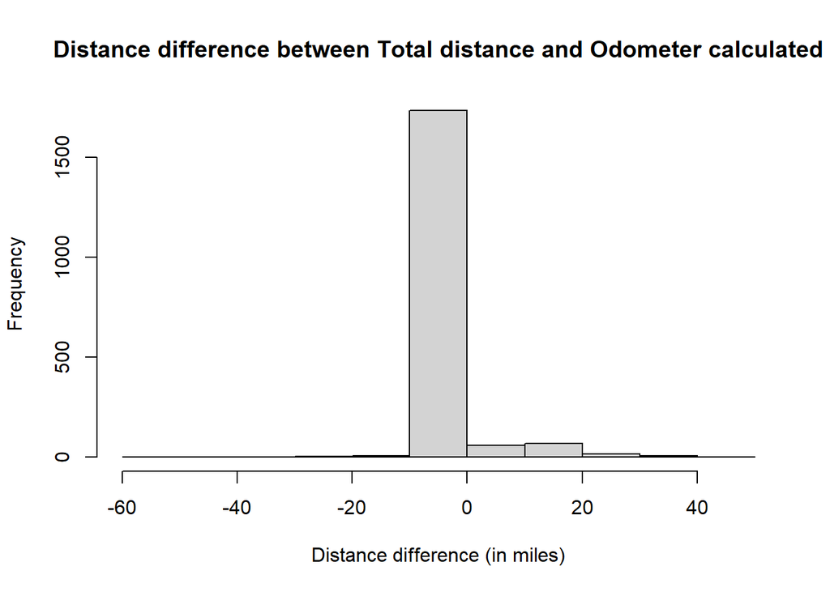

```r
df <- df %>%
  mutate(odometer_distance = `Final Odometer`- `Initial Odometer`,
         distance_difference = `Total Distance` - odometer_distance)

hist(df$distance_difference,
     main = "Distance difference between Total distance and Odometer calculated",
     xlab = "Distance difference (in miles)")
```

Testing average bus speed

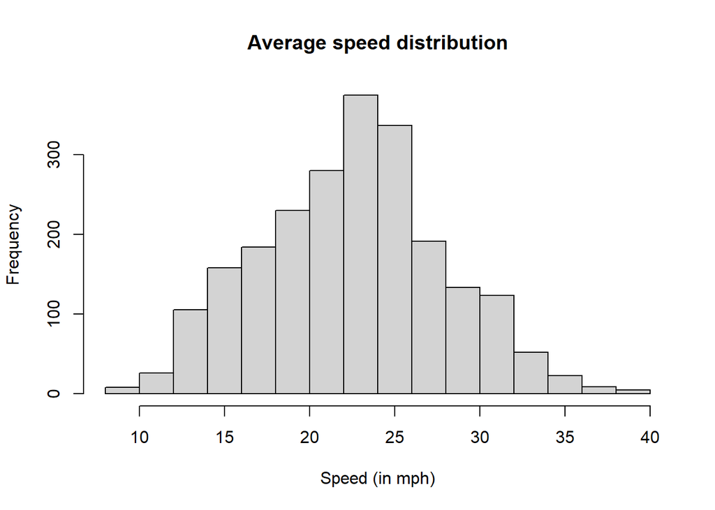

```r
df <- df %>%
  mutate(speed=`Total Distance`/`Driving Time`)

hist(df$speed,
     main = "Average speed distribution",
     xlab = "Speed (in mph)")
```

Cleaning the data to leave only those with distance difference < |5|. GL is the only region with Fuel fired heater and does not have odometer information. We kept all GL data for comparison.

```r
df_clean <- df %>%
  filter(Region == "GL" | (Region != "GL" & distance_difference < abs(5)))
```

Filtering for those with electric heater only

```r
df_electric_heater <- df_clean %>%
  filter(`Fuel Fired Heater?`==FALSE)
```

Filtering for each region

```r
GL_data <- df_clean %>%
  filter(Region=="GL")

NC_data <- df_clean %>%
  filter(Region=="NC")

RM_data <- df_clean %>%
  filter(Region=="RM")

SC_data <- df_clean %>%
  filter(Region=="SC")
```

# Cross Regions comparison

## Creating the data sets to test homogeneity in AVERAGE AMBIENT TEMPERATURE

Getting quantile to create the groups

```r
quantile(df_electric_heater$`Average Ambient Temperature`, c(0.25, .5, .75))
```

```
##      25%      50%      75%
## 58.29444 64.89475 70.97595
```

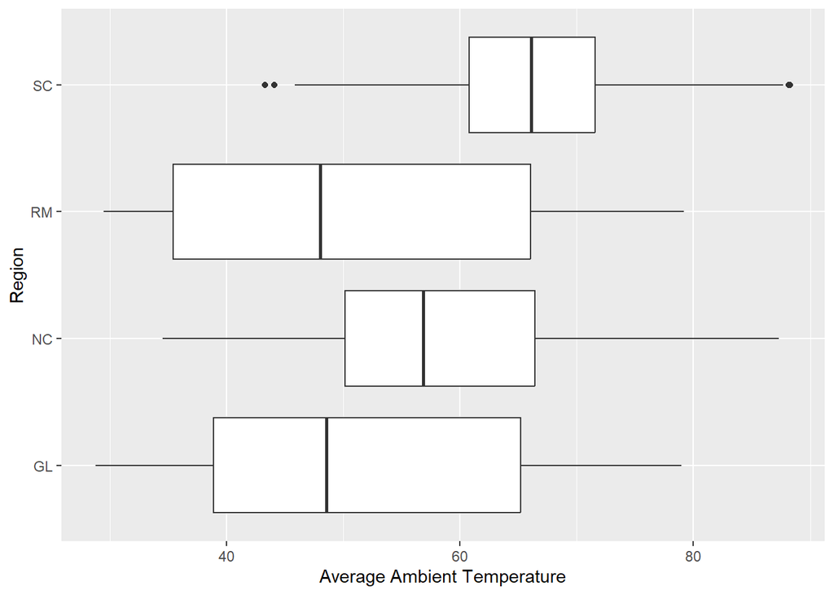

```r
df_clean %>%
  group_by(Region) %>%
  ggplot(aes(x=`Average Ambient Temperature`, y=Region))+
  geom_boxplot()
```

Preparing the df and running the test

```r
temp_homo_test <- df_electric_heater %>%
  group_by(Region) %>%
  summarise("<58"=sum(`Average Ambient Temperature`<58),
            "58-65"=sum((`Average Ambient Temperature`>=58) & (`Average Ambient Temperature`<65)),
            "65-70"=sum((`Average Ambient Temperature`>=65) & (`Average Ambient Temperature`<70)),
            ">70"=sum(`Average Ambient Temperature`>=70))

temp_homo_test
```

```
## # A tibble: 3 × 5
##   Region `<58` `58-65` `65-70` `>70`
##   <chr>  <int>   <int>   <int> <int>
## 1 NC       186      58      37    60
## 2 RM        37       8       9     9
## 3 SC       206     402     324   440
```

The test:
$$H_0: The distribution is the
same across the groups$$
$$H_1: The
distribution is not the same$$

## Running the test:

### Region NC and RM

```r
chisq.test(temp_homo_test[1:2,2:5])
```

```
##
##  Pearson's Chi-squared test
##
## data:  temp_homo_test[1:2, 2:5]
## X-squared = 1.6656, df = 3, p-value = 0.6446
```

We cannot reject the null hypothesis

### Region NC and SC

```r
chisq.test(temp_homo_test[c(1,3),2:5])
```

```
##
##  Pearson's Chi-squared test
##
## data:  temp_homo_test[c(1, 3), 2:5]
## X-squared = 242.59, df = 3, p-value < 2.2e-16
```

We REJECT THE NULL HYPOTHESIS

### Region RM and SC

```r
chisq.test(temp_homo_test[2:3,2:5])
```

```
##
##  Pearson's Chi-squared test
##
## data:  temp_homo_test[2:3, 2:5]
## X-squared = 82.135, df = 3, p-value < 2.2e-16
```

We REJECT THE NULL HYPOTHESIS

## Creating the data sets to test homogeneity in PERCENT OF IDLING TIME

Getting quantile to create the groups

```r
quantile(df_electric_heater$`Percent Idling Time`, c(0.25, .5, .75))
```

```
##       25%       50%       75%
## 0.1061938 0.1736468 0.2457838
```

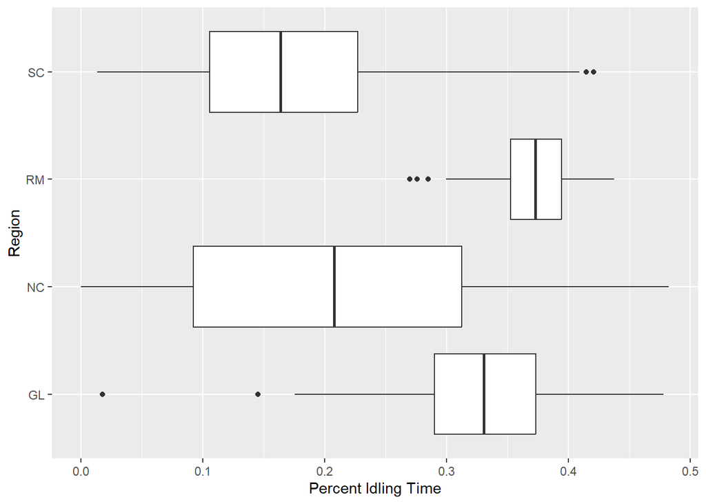

```r
df_clean %>%
  group_by(Region) %>%
  ggplot(aes(x=`Percent Idling Time`, y=Region))+
  geom_boxplot()
```

Preparing the df and running the test

```r
perc_idl_homo_test <- df_electric_heater %>%
  group_by(Region) %>%
  summarise("<10%"=sum(`Percent Idling Time`<0.1),
            "10-17%"=sum((`Percent Idling Time`>=0.1) & (`Percent Idling Time`<0.17)),
            "17-25%"=sum((`Percent Idling Time`>=0.17) & (`Percent Idling Time`<0.25)),
            ">70"=sum(`Percent Idling Time`>=0.25))

perc_idl_homo_test
```

```
## # A tibble: 3 × 5
##   Region `<10%` `10-17%` `17-25%` `>70`
##   <chr>   <int>    <int>    <int> <int>
## 1 NC         92       46       74   129
## 2 RM          0        0        0    63
## 3 SC        309      425      401   237
```

The test:
$$H_0: The distribution is the
same across the groups$$
$$H_1: The
distribution is not the same$$

## Running the test:

### Region NC and RM

```r
chisq.test(perc_idl_homo_test[1:2,2:5])
```

```
##
##  Pearson's Chi-squared test
##
## data:  perc_idl_homo_test[1:2, 2:5]
## X-squared = 82.414, df = 3, p-value < 2.2e-16
```

We REJECT THE NULL HYPOTHESIS

### Region NC and SC

```r
chisq.test(perc_idl_homo_test[c(1,3),2:5])
```

```
##
##  Pearson's Chi-squared test
##
## data:  perc_idl_homo_test[c(1, 3), 2:5]
## X-squared = 92.286, df = 3, p-value < 2.2e-16
```

We REJECT THE NULL HYPOTHESIS

### Region RM and SC

```r
chisq.test(perc_idl_homo_test[2:3,2:5])
```

```
##
##  Pearson's Chi-squared test
##
## data:  perc_idl_homo_test[2:3, 2:5]
## X-squared = 249.29, df = 3, p-value < 2.2e-16
```

We REJECT THE NULL HYPOTHESIS

## Creating the data sets to test homogeneity in IDLING TIME

Getting quantile to create the groups

```r
quantile(df_electric_heater$`Idling Time`, c(0.25, .5, .75))
```

```
##    25%    50%    75%
## 0.2500 0.4500 0.7725
```

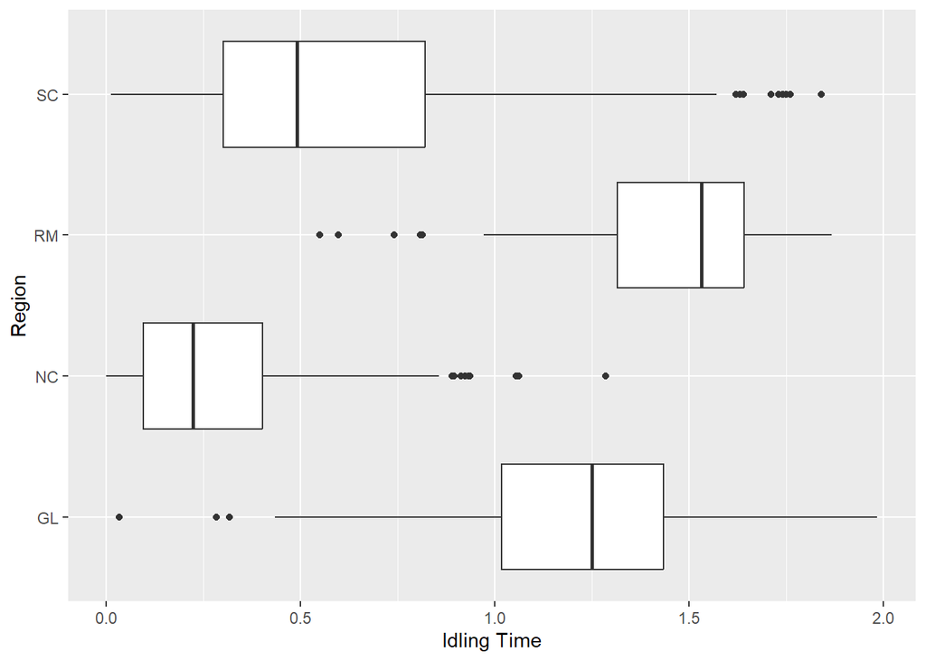

```r
df_clean %>%
  group_by(Region) %>%
  ggplot(aes(x=`Idling Time`, y=Region))+
  geom_boxplot()
```

Preparing the df and running the test

```r
idl_homo_test <- df_electric_heater %>%
  group_by(Region) %>%
  summarise("<0.25"=sum(`Idling Time`<0.25),
            "0.25-0.45"=sum((`Idling Time`>=0.25) & (`Idling Time`<0.45)),
            "0.45-0.77"=sum((`Idling Time`>=0.45) & (`Idling Time`<0.77)),
            ">0.77"=sum(`Idling Time`>=0.77))

idl_homo_test
```

```
## # A tibble: 3 × 5
##   Region `<0.25` `0.25-0.45` `0.45-0.77` `>0.77`
##   <chr>    <int>       <int>       <int>   <int>
## 1 NC         183          88          55      15
## 2 RM           0           0           3      60
## 3 SC         256         352         391     373
```

The test:
$$H_0: The distribution is the
same across the groups$$
$$H_1: The
distribution is not the same$$

## Running the test:

### Region NC and RM

```r
chisq.test(idl_homo_test[1:2,2:5])
```

```
##
##  Pearson's Chi-squared test
##
## data:  idl_homo_test[1:2, 2:5]
## X-squared = 291.22, df = 3, p-value < 2.2e-16
```

We REJECT THE NULL HYPOTHESIS

### Region NC and SC

```r
chisq.test(idl_homo_test[c(1,3),2:5])
```

```
##
##  Pearson's Chi-squared test
##
## data:  idl_homo_test[c(1, 3), 2:5]
## X-squared = 209.27, df = 3, p-value < 2.2e-16
```

We REJECT THE NULL HYPOTHESIS

### Region RM and SC

```r
chisq.test(idl_homo_test[2:3,2:5])
```

```
##
##  Pearson's Chi-squared test
##
## data:  idl_homo_test[2:3, 2:5]
## X-squared = 132.72, df = 3, p-value < 2.2e-16
```

We REJECT THE NULL HYPOTHESIS

## Creating the data sets to test homogeneity in TOTAL ENERGY CONSUMPTION

Getting quantile to create the groups

```r
quantile(df_electric_heater$`Total Energy Consumption`, c(0.25, .5, .75))
```

```
##       25%       50%       75%
##  54.80307 107.90000 149.10000
```

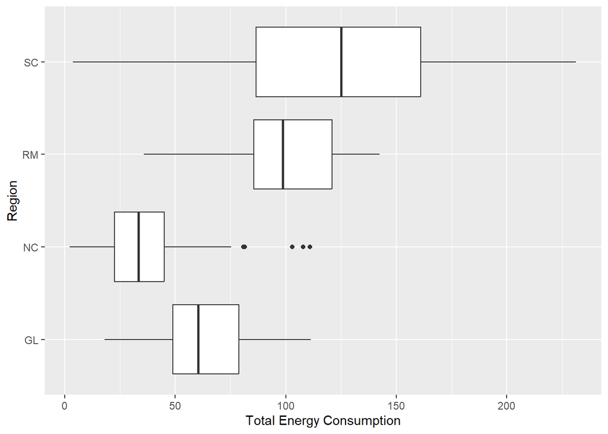

```r
df_clean %>%
  group_by(Region) %>%
  ggplot(aes(x=`Total Energy Consumption`, y=Region))+
  geom_boxplot()
```

Preparing the df and running the test

```r
ene_homo_test <- df_electric_heater %>%
  group_by(Region) %>%
  summarise("<55"=sum(`Total Energy Consumption`<55),
            "55-108"=sum((`Total Energy Consumption`>=55) & (`Total Energy Consumption`<108)),
            "108-149"=sum((`Total Energy Consumption`>=108) & (`Total Energy Consumption`<149)),
            ">149"=sum(`Total Energy Consumption`>=149))

ene_homo_test
```

```
## # A tibble: 3 × 5
##   Region `<55` `55-108` `108-149` `>149`
##   <chr>  <int>    <int>     <int>  <int>
## 1 NC       290       50         1      0
## 2 RM         5       32        26      0
## 3 SC       152      361       408    451
```

The test:
$$H_0: The distribution is the
same across the groups$$
$$H_1: The
distribution is not the same$$

## Running the test:

### Region NC and RM

```r
chisq.test(ene_homo_test[1:2,2:4])
```

```
##
##  Pearson's Chi-squared test
##
## data:  ene_homo_test[1:2, 2:4]
## X-squared = 211.1, df = 2, p-value < 2.2e-16
```

We REJECT THE NULL HYPOTHESIS

### Region NC and SC

```r
chisq.test(ene_homo_test[c(1,3),2:5])
```

```
##
##  Pearson's Chi-squared test
##
## data:  ene_homo_test[c(1, 3), 2:5]
## X-squared = 805.8, df = 3, p-value < 2.2e-16
```

We REJECT THE NULL HYPOTHESIS

### Region RM and SC

```r
chisq.test(ene_homo_test[2:3,2:5])
```

```
##
##  Pearson's Chi-squared test
##
## data:  ene_homo_test[2:3, 2:5]
## X-squared = 37.084, df = 3, p-value = 4.418e-08
```

We REJECT THE NULL HYPOTHESIS

# Some Data Visualization

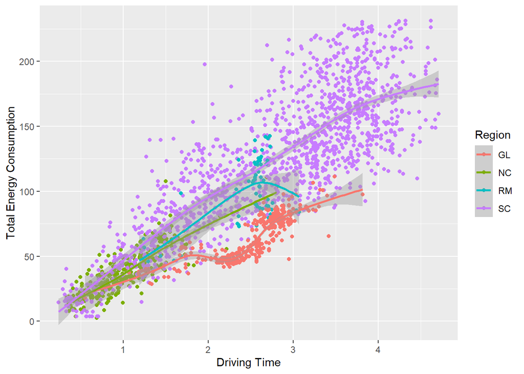

```r
df_clean %>%
  ggplot(aes(x=`Driving Time`, y=`Total Energy Consumption`, colour = Region))+
  geom_point()+
  geom_smooth()
```

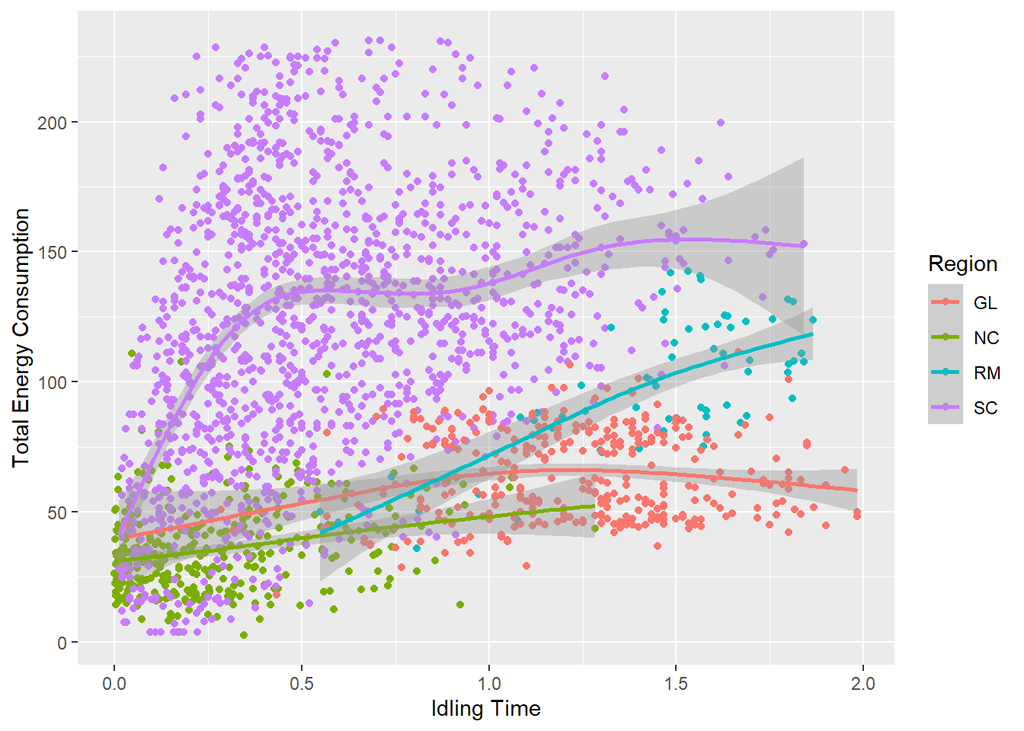

```r
df_clean %>%
  ggplot(aes(x=`Idling Time`, y=`Total Energy Consumption`, colour = Region))+
  geom_point()+
  geom_smooth()
```

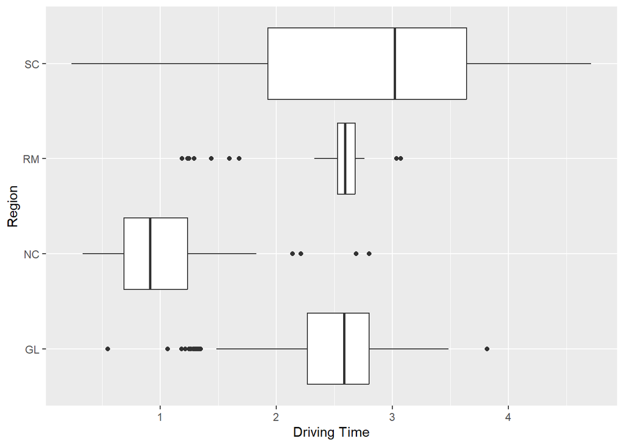

```r
df_clean %>%
  ggplot(aes(x=`Driving Time`, y=Region))+
  geom_boxplot()
```

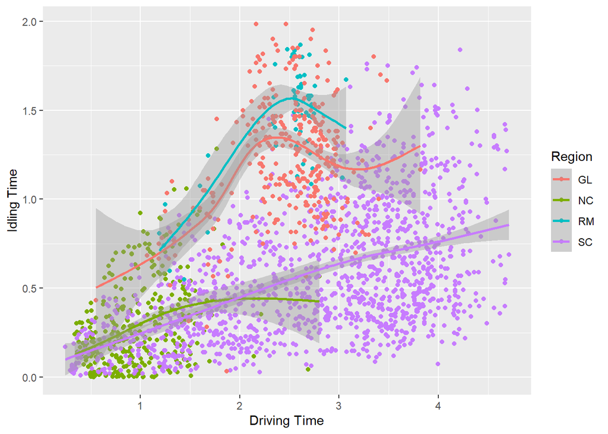

```r
df_clean %>%
  ggplot(aes(x=`Driving Time`, y=`Idling Time`, colour = Region))+
  geom_point()+
  geom_smooth()
```

# Regression analysis

## For all regions with electric heater

### Linear with idling time and driving time

```r
reg1 <- lm(`Total Energy Consumption` ~ `Idling Time` + `Driving Time`, data = df_electric_heater)

summary(reg1)
```

```
##
## Call:
## lm(formula = `Total Energy Consumption` ~ `Idling Time` + `Driving Time`,
##     data = df_electric_heater)
##
## Residuals:
##     Min      1Q  Median      3Q     Max
## -90.043 -14.856  -2.915  13.276 110.736
##
## Coefficients:
##                Estimate Std. Error t value Pr(>|t|)
## (Intercept)      2.1027     1.4088   1.493    0.136
## `Idling Time`  -11.1744     1.7902  -6.242 5.39e-10 ***
## `Driving Time`  45.4629     0.6015  75.588  < 2e-16 ***
## ---
## Signif. codes:  0 '***' 0.001 '**' 0.01 '*' 0.05 '.' 0.1 ' ' 1
##
## Residual standard error: 25.75 on 1773 degrees of freedom
## Multiple R-squared:  0.8012, Adjusted R-squared:  0.801
## F-statistic:  3573 on 2 and 1773 DF,  p-value: < 2.2e-16
```

### Linear with idling time, driving time, and ambient temperature

```r
reg2 <- lm(`Total Energy Consumption` ~ `Idling Time` + `Driving Time` + `Average Ambient Temperature`, data = df_electric_heater)

summary(reg2)
```

```
##
## Call:
## lm(formula = `Total Energy Consumption` ~ `Idling Time` + `Driving Time` +
##     `Average Ambient Temperature`, data = df_electric_heater)
##
## Residuals:
##     Min      1Q  Median      3Q     Max
## -90.571 -14.717  -3.007  13.411 109.373
##
## Coefficients:
##                                Estimate Std. Error t value Pr(>|t|)
## (Intercept)                    15.97721    4.23286   3.775 0.000166 ***
## `Idling Time`                 -12.28717    1.81315  -6.777 1.67e-11 ***
## `Driving Time`                 45.93017    0.61448  74.746  < 2e-16 ***
## `Average Ambient Temperature`  -0.22383    0.06442  -3.475 0.000524 ***
## ---
## Signif. codes:  0 '***' 0.001 '**' 0.01 '*' 0.05 '.' 0.1 ' ' 1
##
## Residual standard error: 25.67 on 1772 degrees of freedom
## Multiple R-squared:  0.8025, Adjusted R-squared:  0.8022
## F-statistic:  2401 on 3 and 1772 DF,  p-value: < 2.2e-16
```

### Log-log with idling time and driving time

```r
df_electric_heater$`Total Energy Consumption`[df_electric_heater$`Total Energy Consumption` == 0] <- 0.0001
df_electric_heater$`Idling Time`[df_electric_heater$`Idling Time` == 0] <- 0.0001
df_electric_heater$`Driving Time`[df_electric_heater$`Driving Time` == 0] <- 0.0001

reg3 <- lm(log(`Total Energy Consumption`) ~ log(`Idling Time`) + log(`Driving Time`), data = df_electric_heater, na.action=na.omit)

summary(reg3)
```

```
##
## Call:
## lm(formula = log(`Total Energy Consumption`) ~ log(`Idling Time`) +
##     log(`Driving Time`), data = df_electric_heater, na.action = na.omit)
##
## Residuals:
##     Min      1Q  Median      3Q     Max
## -2.3324 -0.1588  0.0065  0.1662  1.2058
##
## Coefficients:
##                      Estimate Std. Error t value Pr(>|t|)
## (Intercept)          3.604970   0.017144 210.278  < 2e-16 ***
## log(`Idling Time`)  -0.033592   0.008243  -4.075  4.8e-05 ***
## log(`Driving Time`)  1.125940   0.013468  83.601  < 2e-16 ***
## ---
## Signif. codes:  0 '***' 0.001 '**' 0.01 '*' 0.05 '.' 0.1 ' ' 1
##
## Residual standard error: 0.2944 on 1773 degrees of freedom
## Multiple R-squared:  0.8506, Adjusted R-squared:  0.8505
## F-statistic:  5049 on 2 and 1773 DF,  p-value: < 2.2e-16
```

For all these regressions, we see a NEGATIVE coefficient for Idling time. However, for the linear regressions all coefficients are close, as temperature seems to have little effect in energy consumption. We also see a driving time coefficient close to 45 (this can be compared to the benchmark data that follows).

### Comparing coefficients

```r
export_summs(reg1, reg2, reg3)
```

|  | Model 1 | Model 2 | Model 3 |
| --- | --- | --- | --- |
| (Intercept) | 2.10 | 15.98 *** | 3.60 *** |
|  | (1.41) | (4.23) | (0.02) |
| `Idling Time` | -11.17 *** | -12.29 *** |  |
|  | (1.79) | (1.81) |  |
| `Driving Time` | 45.46 *** | 45.93 *** |  |
|  | (0.60) | (0.61) |  |
| `Average Ambient Temperature` |  | -0.22 *** |  |
|  |  | (0.06) |  |
| log(`Idling Time`) |  |  | -0.03 *** |
|  |  |  | (0.01) |
| log(`Driving Time`) |  |  | 1.13 *** |
|  |  |  | (0.01) |
| N | 1776 | 1776 | 1776 |
| R2 | 0.80 | 0.80 | 0.85 |
| *** p < 0.001; ** p < 0.01; * p < 0.05. |  |  |  |

R-square for both linear regressions is the same. With the log function presenting a better fit

### Plotting observed and predicted values

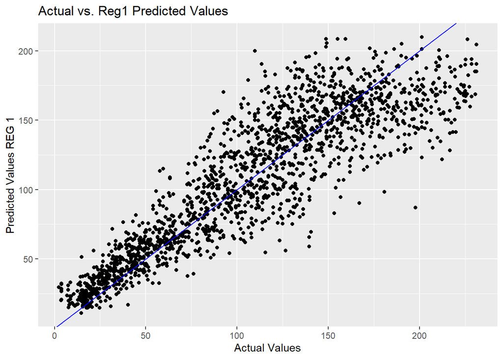

```r
all_reg_plot <- df_electric_heater %>%
  select(`Total Energy Consumption`,
         `Idling Time`,
         `Average Ambient Temperature`,
         `Driving Time`)

all_reg_plot <- all_reg_plot %>%
  mutate(reg1 = fitted.values(reg1),
         reg2 = fitted.values(reg2),
         reg3 = fitted.values(reg3))

all_reg_plot %>%
  ggplot(aes(x = `Total Energy Consumption`, y = reg1))+
  geom_point()+
  geom_abline(intercept=0, slope=1, color="blue") +
  labs(x='Actual Values', y='Predicted Values REG 1', title='Actual vs. Reg1 Predicted Values')
```

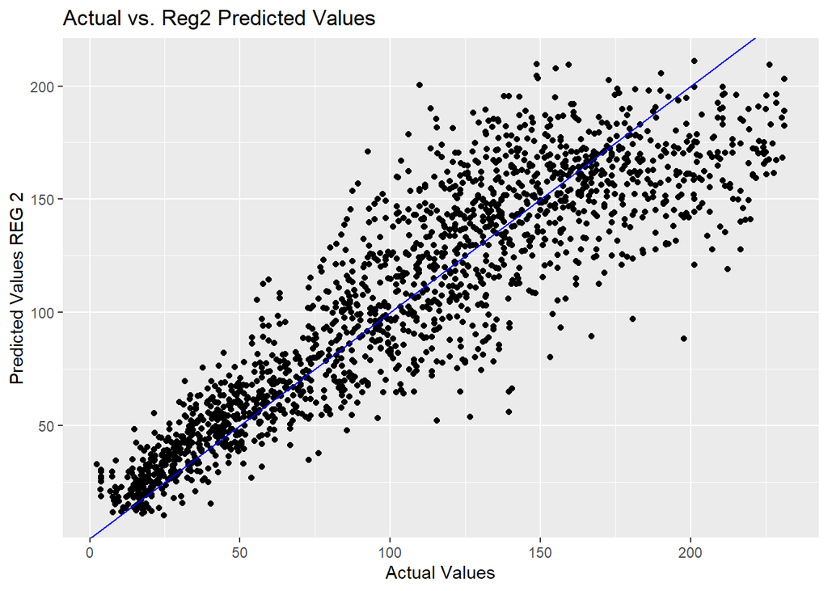

```r
all_reg_plot %>%
  ggplot(aes(x = `Total Energy Consumption`, y = reg2))+
  geom_point()+
  geom_abline(intercept=0, slope=1, color="blue") +
  labs(x='Actual Values', y='Predicted Values REG 2', title='Actual vs. Reg2 Predicted Values')
```

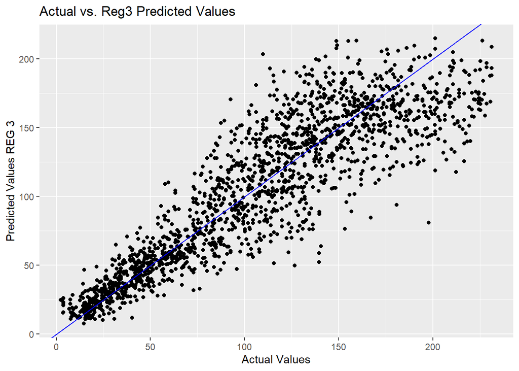

```r
all_reg_plot %>%
  ggplot(aes(x = `Total Energy Consumption`, y = exp(reg3)))+
  geom_point()+
  geom_abline(intercept=0, slope=1, color="blue") +
  labs(x='Actual Values', y='Predicted Values REG 3', title='Actual vs. Reg3 Predicted Values')
```

## For GL region - Bechmark

### Linear with idling time and driving time

```r
GL_reg1 <- lm(`Total Energy Consumption` ~ `Idling Time` + `Driving Time`, data = GL_data)

summary(GL_reg1)
```

```
##
## Call:
## lm(formula = `Total Energy Consumption` ~ `Idling Time` + `Driving Time`,
##     data = GL_data)
##
## Residuals:
##     Min      1Q  Median      3Q     Max
## -30.418  -7.144  -1.106   7.472  28.202
##
## Coefficients:
##                Estimate Std. Error t value Pr(>|t|)
## (Intercept)      -3.707      3.209  -1.155    0.249
## `Idling Time`    -9.210      1.719  -5.357 1.59e-07 ***
## `Driving Time`   31.620      1.200  26.345  < 2e-16 ***
## ---
## Signif. codes:  0 '***' 0.001 '**' 0.01 '*' 0.05 '.' 0.1 ' ' 1
##
## Residual standard error: 9.641 on 330 degrees of freedom
## Multiple R-squared:  0.6788, Adjusted R-squared:  0.6769
## F-statistic: 348.7 on 2 and 330 DF,  p-value: < 2.2e-16
```

In this case, it makes sense to have idling time with a negative coefficient, since it’s not consuming any energy from the battery. Driving time coefficient is 31, a little bit less then the observed in the regressions for all regions that use electric heater. It should make difference to add the ambient temperature in this equation but we will test this as well.

### Linear with idling time, driving time, and ambient temperature

```r
GL_reg2 <- lm(`Total Energy Consumption` ~ `Idling Time` + `Driving Time` + `Average Ambient Temperature`, data = GL_data)

summary(GL_reg2)
```

```
##
## Call:
## lm(formula = `Total Energy Consumption` ~ `Idling Time` + `Driving Time` +
##     `Average Ambient Temperature`, data = GL_data)
##
## Residuals:
##     Min      1Q  Median      3Q     Max
## -33.156  -6.849  -0.699   6.644  25.926
##
## Coefficients:
##                               Estimate Std. Error t value Pr(>|t|)
## (Intercept)                    5.59079    3.32643   1.681   0.0938 .
## `Idling Time`                 -9.41307    1.61692  -5.822 1.39e-08 ***
## `Driving Time`                32.66154    1.13953  28.662  < 2e-16 ***
## `Average Ambient Temperature` -0.22963    0.03456  -6.645 1.26e-10 ***
## ---
## Signif. codes:  0 '***' 0.001 '**' 0.01 '*' 0.05 '.' 0.1 ' ' 1
##
## Residual standard error: 9.066 on 329 degrees of freedom
## Multiple R-squared:  0.7168, Adjusted R-squared:  0.7142
## F-statistic: 277.6 on 3 and 329 DF,  p-value: < 2.2e-16
```

Though small, the effect of ambient temperature is still statistically significant in this case.

### Log-log with idling time and driving time

```r
GL_data$`Total Energy Consumption`[GL_data$`Total Energy Consumption` == 0] <- 0.0001
GL_data$`Idling Time`[GL_data$`Idling Time` == 0] <- 0.0001
GL_data$`Driving Time`[GL_data$`Driving Time` == 0] <- 0.0001

GL_reg3 <- lm(log(`Total Energy Consumption`) ~ log(`Idling Time`) + log(`Driving Time`), data = GL_data, na.action=na.omit)

summary(GL_reg3)
```

```
##
## Call:
## lm(formula = log(`Total Energy Consumption`) ~ log(`Idling Time`) +
##     log(`Driving Time`), data = GL_data, na.action = na.omit)
##
## Residuals:
##      Min       1Q   Median       3Q      Max
## -0.46540 -0.12011 -0.00348  0.12982  0.48180
##
## Coefficients:
##                     Estimate Std. Error t value Pr(>|t|)
## (Intercept)          3.17780    0.03798  83.679  < 2e-16 ***
## log(`Idling Time`)  -0.12744    0.02734  -4.662 4.55e-06 ***
## log(`Driving Time`)  1.07783    0.04282  25.174  < 2e-16 ***
## ---
## Signif. codes:  0 '***' 0.001 '**' 0.01 '*' 0.05 '.' 0.1 ' ' 1
##
## Residual standard error: 0.1609 on 330 degrees of freedom
## Multiple R-squared:  0.6645, Adjusted R-squared:  0.6625
## F-statistic: 326.8 on 2 and 330 DF,  p-value: < 2.2e-16
```

### Comparing coefficients

```r
export_summs(GL_reg1, GL_reg2, GL_reg3)
```

|  | Model 1 | Model 2 | Model 3 |
| --- | --- | --- | --- |
| (Intercept) | -3.71 | 5.59 | 3.18 *** |
|  | (3.21) | (3.33) | (0.04) |
| `Idling Time` | -9.21 *** | -9.41 *** |  |
|  | (1.72) | (1.62) |  |
| `Driving Time` | 31.62 *** | 32.66 *** |  |
|  | (1.20) | (1.14) |  |
| `Average Ambient Temperature` |  | -0.23 *** |  |
|  |  | (0.03) |  |
| log(`Idling Time`) |  |  | -0.13 *** |
|  |  |  | (0.03) |
| log(`Driving Time`) |  |  | 1.08 *** |
|  |  |  | (0.04) |
| N | 333 | 333 | 333 |
| R2 | 0.68 | 0.72 | 0.66 |
| *** p < 0.001; ** p < 0.01; * p < 0.05. |  |  |  |

## For RM region

### Linear with idling time and driving time

```r
RM_reg1 <- lm(`Total Energy Consumption` ~ `Idling Time` + `Driving Time`, data = RM_data)

summary(RM_reg1)
```

```
##
## Call:
## lm(formula = `Total Energy Consumption` ~ `Idling Time` + `Driving Time`,
##     data = RM_data)
##
## Residuals:
##     Min      1Q  Median      3Q     Max
## -33.842 -15.079  -2.041  14.851  38.335
##
## Coefficients:
##                Estimate Std. Error t value Pr(>|t|)
## (Intercept)      -2.933     13.731  -0.214 0.831558
## `Idling Time`    43.903     10.547   4.163 0.000102 ***
## `Driving Time`   15.477      7.619   2.031 0.046656 *
## ---
## Signif. codes:  0 '***' 0.001 '**' 0.01 '*' 0.05 '.' 0.1 ' ' 1
##
## Residual standard error: 18.18 on 60 degrees of freedom
## Multiple R-squared:  0.5219, Adjusted R-squared:  0.506
## F-statistic: 32.75 on 2 and 60 DF,  p-value: 2.424e-10
```

Idling time in this case has a bigger coefficient than driving time alone.

It makes a little bit of sense when we see that the idling time for this region is way greater than for the others:

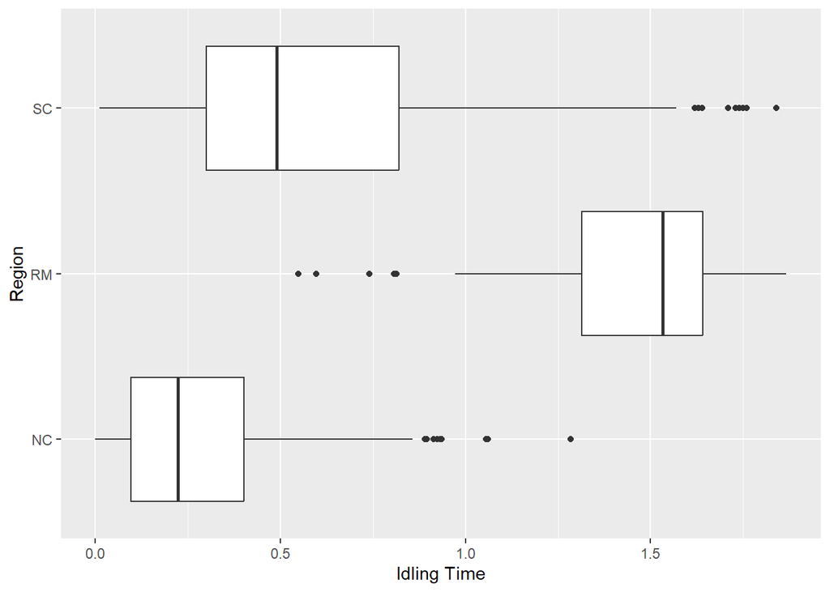

```r
df_electric_heater %>%
  group_by(Region) %>%
  ggplot(aes(x=`Idling Time`, y=Region))+
  geom_boxplot()
```

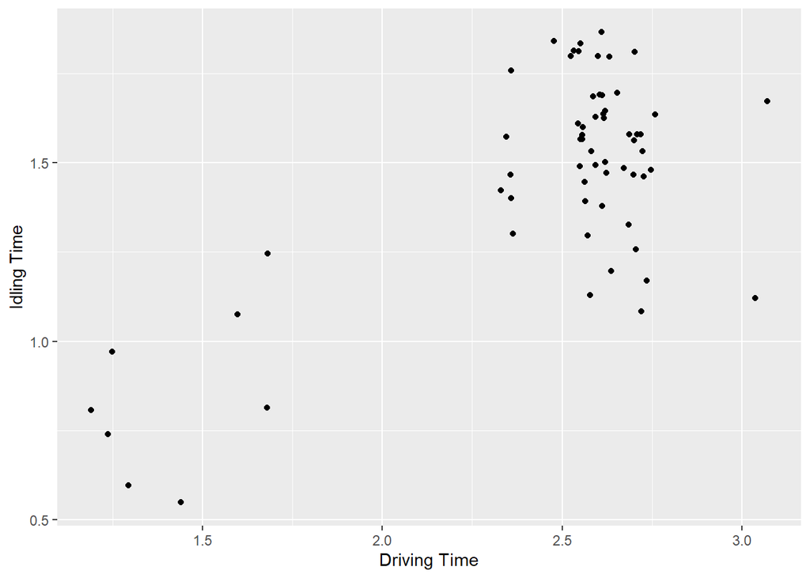

```r
RM_data %>%
  ggplot(aes(x=`Driving Time`, y=`Idling Time`))+
  geom_point()
```

### Linear with idling time, driving time, and ambient temperature

```r
RM_reg2 <- lm(`Total Energy Consumption` ~ `Idling Time` + `Driving Time` + `Average Ambient Temperature`, data = RM_data)

summary(RM_reg2)
```

```
##
## Call:
## lm(formula = `Total Energy Consumption` ~ `Idling Time` + `Driving Time` +
##     `Average Ambient Temperature`, data = RM_data)
##
## Residuals:
##     Min      1Q  Median      3Q     Max
## -25.661  -6.273  -2.832   7.155  20.382
##
## Coefficients:
##                               Estimate Std. Error t value Pr(>|t|)
## (Intercept)                   59.27942    9.38895   6.314 3.88e-08 ***
## `Idling Time`                 12.55372    6.49685   1.932   0.0581 .
## `Driving Time`                30.03984    4.44545   6.757 6.95e-09 ***
## `Average Ambient Temperature` -1.02788    0.08921 -11.522  < 2e-16 ***
## ---
## Signif. codes:  0 '***' 0.001 '**' 0.01 '*' 0.05 '.' 0.1 ' ' 1
##
## Residual standard error: 10.17 on 59 degrees of freedom
## Multiple R-squared:  0.8529, Adjusted R-squared:  0.8454
## F-statistic:   114 on 3 and 59 DF,  p-value: < 2.2e-16
```

### Log-log with idling time and driving time

```r
RM_reg3 <- lm(log(`Total Energy Consumption`) ~ log(`Idling Time`) + log(`Driving Time`), data = RM_data)

summary(RM_reg3)
```

```
##
## Call:
## lm(formula = log(`Total Energy Consumption`) ~ log(`Idling Time`) +
##     log(`Driving Time`), data = RM_data)
##
## Residuals:
##      Min       1Q   Median       3Q      Max
## -0.36033 -0.15988 -0.00976  0.14835  0.32402
##
## Coefficients:
##                     Estimate Std. Error t value Pr(>|t|)
## (Intercept)           3.9458     0.1188  33.201  < 2e-16 ***
## log(`Idling Time`)    0.5892     0.1428   4.126 0.000115 ***
## log(`Driving Time`)   0.4605     0.1711   2.692 0.009198 **
## ---
## Signif. codes:  0 '***' 0.001 '**' 0.01 '*' 0.05 '.' 0.1 ' ' 1
##
## Residual standard error: 0.1857 on 60 degrees of freedom
## Multiple R-squared:  0.6329, Adjusted R-squared:  0.6207
## F-statistic: 51.73 on 2 and 60 DF,  p-value: 8.759e-14
```

In this case, the idling time has more impact in energy consumed than driving time.

### Comparing coefficients

```r
export_summs(RM_reg1, RM_reg2, RM_reg3)
```

|  | Model 1 | Model 2 | Model 3 |
| --- | --- | --- | --- |
| (Intercept) | -2.93 | 59.28 *** | 3.95 *** |
|  | (13.73) | (9.39) | (0.12) |
| `Idling Time` | 43.90 *** | 12.55 |  |
|  | (10.55) | (6.50) |  |
| `Driving Time` | 15.48 * | 30.04 *** |  |
|  | (7.62) | (4.45) |  |
| `Average Ambient Temperature` |  | -1.03 *** |  |
|  |  | (0.09) |  |
| log(`Idling Time`) |  |  | 0.59 *** |
|  |  |  | (0.14) |
| log(`Driving Time`) |  |  | 0.46 ** |
|  |  |  | (0.17) |
| N | 63 | 63 | 63 |
| R2 | 0.52 | 0.85 | 0.63 |
| *** p < 0.001; ** p < 0.01; * p < 0.05. |  |  |  |

## For SC region

This region seems to be the one with greater range in terms of all three variables considered

### Linear with idling time and driving time

```r
SC_reg1 <- lm(`Total Energy Consumption` ~ `Idling Time` + `Driving Time`, data = SC_data)

summary(SC_reg1)
```

```
##
## Call:
## lm(formula = `Total Energy Consumption` ~ `Idling Time` + `Driving Time`,
##     data = SC_data)
##
## Residuals:
##     Min      1Q  Median      3Q     Max
## -88.278 -18.054  -2.608  16.456 106.713
##
## Coefficients:
##                Estimate Std. Error t value Pr(>|t|)
## (Intercept)     11.4698     2.1401   5.359 9.79e-08 ***
## `Idling Time`  -13.5781     2.4447  -5.554 3.35e-08 ***
## `Driving Time`  43.2024     0.8327  51.883  < 2e-16 ***
## ---
## Signif. codes:  0 '***' 0.001 '**' 0.01 '*' 0.05 '.' 0.1 ' ' 1
##
## Residual standard error: 28.15 on 1369 degrees of freedom
## Multiple R-squared:  0.7052, Adjusted R-squared:  0.7047
## F-statistic:  1637 on 2 and 1369 DF,  p-value: < 2.2e-16
```

### Linear with idling time, driving time, and ambient temperature

```r
SC_reg2 <- lm(`Total Energy Consumption` ~ `Idling Time` + `Driving Time` + `Average Ambient Temperature`, data = SC_data)

summary(SC_reg2)
```

```
##
## Call:
## lm(formula = `Total Energy Consumption` ~ `Idling Time` + `Driving Time` +
##     `Average Ambient Temperature`, data = SC_data)
##
## Residuals:
##     Min      1Q  Median      3Q     Max
## -87.998 -18.750  -2.759  16.296 103.416
##
## Coefficients:
##                                Estimate Std. Error t value Pr(>|t|)
## (Intercept)                    38.08857    6.89509   5.524 3.96e-08 ***
## `Idling Time`                 -13.65169    2.43102  -5.616 2.37e-08 ***
## `Driving Time`                 43.15377    0.82811  52.111  < 2e-16 ***
## `Average Ambient Temperature`  -0.39929    0.09838  -4.059 5.21e-05 ***
## ---
## Signif. codes:  0 '***' 0.001 '**' 0.01 '*' 0.05 '.' 0.1 ' ' 1
##
## Residual standard error: 28 on 1368 degrees of freedom
## Multiple R-squared:  0.7087, Adjusted R-squared:  0.708
## F-statistic:  1109 on 3 and 1368 DF,  p-value: < 2.2e-16
```

### Log-log with idling time and driving time

```r
SC_reg3 <- lm(log(`Total Energy Consumption`) ~ log(`Idling Time`) + log(`Driving Time`), data = SC_data)

summary(SC_reg3)
```

```
##
## Call:
## lm(formula = log(`Total Energy Consumption`) ~ log(`Idling Time`) +
##     log(`Driving Time`), data = SC_data)
##
## Residuals:
##     Min      1Q  Median      3Q     Max
## -2.0639 -0.1464  0.0063  0.1705  1.0187
##
## Coefficients:
##                     Estimate Std. Error t value Pr(>|t|)
## (Intercept)          3.65898    0.02537 144.203  < 2e-16 ***
## log(`Idling Time`)  -0.05290    0.01226  -4.315 1.71e-05 ***
## log(`Driving Time`)  1.07404    0.01852  57.983  < 2e-16 ***
## ---
## Signif. codes:  0 '***' 0.001 '**' 0.01 '*' 0.05 '.' 0.1 ' ' 1
##
## Residual standard error: 0.2917 on 1369 degrees of freedom
## Multiple R-squared:  0.7783, Adjusted R-squared:  0.778
## F-statistic:  2403 on 2 and 1369 DF,  p-value: < 2.2e-16
```

### Comparing coefficients

```r
export_summs(SC_reg1, SC_reg2, SC_reg3)
```

|  | Model 1 | Model 2 | Model 3 |
| --- | --- | --- | --- |
| (Intercept) | 11.47 *** | 38.09 *** | 3.66 *** |
|  | (2.14) | (6.90) | (0.03) |
| `Idling Time` | -13.58 *** | -13.65 *** |  |
|  | (2.44) | (2.43) |  |
| `Driving Time` | 43.20 *** | 43.15 *** |  |
|  | (0.83) | (0.83) |  |
| `Average Ambient Temperature` |  | -0.40 *** |  |
|  |  | (0.10) |  |
| log(`Idling Time`) |  |  | -0.05 *** |
|  |  |  | (0.01) |
| log(`Driving Time`) |  |  | 1.07 *** |
|  |  |  | (0.02) |
| N | 1372 | 1372 | 1372 |
| R2 | 0.71 | 0.71 | 0.78 |
| *** p < 0.001; ** p < 0.01; * p < 0.05. |  |  |  |

For all regressions for SC region, we also got a negative coefficient for idling time.

## For NC region

### Linear with idling time and driving time

```r
NC_reg1 <- lm(`Total Energy Consumption` ~ `Idling Time` + `Driving Time`, data = NC_data)

summary(NC_reg1)
```

```
##
## Call:
## lm(formula = `Total Energy Consumption` ~ `Idling Time` + `Driving Time`,
##     data = NC_data)
##
## Residuals:
##     Min      1Q  Median      3Q     Max
## -28.315  -4.953  -0.456   4.896  51.066
##
## Coefficients:
##                Estimate Std. Error t value Pr(>|t|)
## (Intercept)      -1.004      1.297  -0.774    0.440
## `Idling Time`    -2.783      2.108  -1.320    0.188
## `Driving Time`   38.795      1.314  29.529   <2e-16 ***
## ---
## Signif. codes:  0 '***' 0.001 '**' 0.01 '*' 0.05 '.' 0.1 ' ' 1
##
## Residual standard error: 8.76 on 338 degrees of freedom
## Multiple R-squared:  0.7398, Adjusted R-squared:  0.7382
## F-statistic: 480.4 on 2 and 338 DF,  p-value: < 2.2e-16
```

### Linear with idling time, driving time, and ambient temperature

```r
NC_reg2 <- lm(`Total Energy Consumption` ~ `Idling Time` + `Driving Time` + `Average Ambient Temperature`, data = NC_data)

summary(NC_reg2)
```

```
##
## Call:
## lm(formula = `Total Energy Consumption` ~ `Idling Time` + `Driving Time` +
##     `Average Ambient Temperature`, data = NC_data)
##
## Residuals:
##     Min      1Q  Median      3Q     Max
## -29.397  -4.658  -0.590   4.710  50.357
##
## Coefficients:
##                               Estimate Std. Error t value Pr(>|t|)
## (Intercept)                    2.33127    2.93929   0.793    0.428
## `Idling Time`                 -3.03104    2.11493  -1.433    0.153
## `Driving Time`                38.63944    1.31834  29.309   <2e-16 ***
## `Average Ambient Temperature` -0.05279    0.04175  -1.264    0.207
## ---
## Signif. codes:  0 '***' 0.001 '**' 0.01 '*' 0.05 '.' 0.1 ' ' 1
##
## Residual standard error: 8.753 on 337 degrees of freedom
## Multiple R-squared:  0.741,  Adjusted R-squared:  0.7387
## F-statistic: 321.4 on 3 and 337 DF,  p-value: < 2.2e-16
```

### Log-log with idling time and driving time

```r
NC_data$`Total Energy Consumption`[NC_data$`Total Energy Consumption` == 0] <- 0.0001
NC_data$`Idling Time`[NC_data$`Idling Time` == 0] <- 0.0001
NC_data$`Driving Time`[NC_data$`Driving Time` == 0] <- 0.0001

NC_reg3 <- lm(log(`Total Energy Consumption`) ~ log(`Idling Time`) + log(`Driving Time`), data = NC_data)

summary(NC_reg3)
```

```
##
## Call:
## lm(formula = log(`Total Energy Consumption`) ~ log(`Idling Time`) +
##     log(`Driving Time`), data = NC_data)
##
## Residuals:
##      Min       1Q   Median       3Q      Max
## -2.27363 -0.12372  0.02267  0.16008  0.68303
##
## Coefficients:
##                     Estimate Std. Error t value Pr(>|t|)
## (Intercept)          3.54051    0.02624 134.926   <2e-16 ***
## log(`Idling Time`)  -0.01924    0.01176  -1.636    0.103
## log(`Driving Time`)  1.07018    0.04060  26.358   <2e-16 ***
## ---
## Signif. codes:  0 '***' 0.001 '**' 0.01 '*' 0.05 '.' 0.1 ' ' 1
##
## Residual standard error: 0.2927 on 338 degrees of freedom
## Multiple R-squared:  0.6812, Adjusted R-squared:  0.6793
## F-statistic:   361 on 2 and 338 DF,  p-value: < 2.2e-16
```

### Comparing coefficients

```r
export_summs(NC_reg1, NC_reg2, NC_reg3)
```

|  | Model 1 | Model 2 | Model 3 |
| --- | --- | --- | --- |
| (Intercept) | -1.00 | 2.33 | 3.54 *** |
|  | (1.30) | (2.94) | (0.03) |
| `Idling Time` | -2.78 | -3.03 |  |
|  | (2.11) | (2.11) |  |
| `Driving Time` | 38.79 *** | 38.64 *** |  |
|  | (1.31) | (1.32) |  |
| `Average Ambient Temperature` |  | -0.05 |  |
|  |  | (0.04) |  |
| log(`Idling Time`) |  |  | -0.02 |
|  |  |  | (0.01) |
| log(`Driving Time`) |  |  | 1.07 *** |
|  |  |  | (0.04) |
| N | 341 | 341 | 341 |
| R2 | 0.74 | 0.74 | 0.68 |
| *** p < 0.001; ** p < 0.01; * p < 0.05. |  |  |  |

For this one, all idling time are negative and not significant.

# Comparing log-log regressions for all regions and for SC region, both with best R-sqaure

```r
export_summs(reg3, SC_reg3)
```

|  | Model 1 | Model 2 |
| --- | --- | --- |
| (Intercept) | 3.60 *** | 3.66 *** |
|  | (0.02) | (0.03) |
| log(`Idling Time`) | -0.03 *** | -0.05 *** |
|  | (0.01) | (0.01) |
| log(`Driving Time`) | 1.13 *** | 1.07 *** |
|  | (0.01) | (0.02) |
| N | 1776 | 1372 |
| R2 | 0.85 | 0.78 |
| *** p < 0.001; ** p < 0.01; * p < 0.05. |  |  |

## SC log-log regression with ambient temperature

```r
SC_reg4 <- lm(log(`Total Energy Consumption`) ~ log(`Idling Time`) + log(`Driving Time`) + log(`Average Ambient Temperature`), data = SC_data)

summary(SC_reg4)
```

```
##
## Call:
## lm(formula = log(`Total Energy Consumption`) ~ log(`Idling Time`) +
##     log(`Driving Time`) + log(`Average Ambient Temperature`),
##     data = SC_data)
##
## Residuals:
##      Min       1Q   Median       3Q      Max
## -2.05088 -0.14924  0.00935  0.16613  1.02483
##
## Coefficients:
##                                    Estimate Std. Error t value Pr(>|t|)
## (Intercept)                         4.73374    0.28200  16.786  < 2e-16 ***
## log(`Idling Time`)                 -0.05291    0.01220  -4.337 1.55e-05 ***
## log(`Driving Time`)                 1.06993    0.01846  57.950  < 2e-16 ***
## log(`Average Ambient Temperature`) -0.25585    0.06686  -3.827 0.000136 ***
## ---
## Signif. codes:  0 '***' 0.001 '**' 0.01 '*' 0.05 '.' 0.1 ' ' 1
##
## Residual standard error: 0.2902 on 1368 degrees of freedom
## Multiple R-squared:  0.7806, Adjusted R-squared:  0.7802
## F-statistic:  1623 on 3 and 1368 DF,  p-value: < 2.2e-16
```